# How to handle CDS Tourism data

#### More advanced plotting and Zooming in on Zuid-Holland

We want to zoom in on Zuid-Holland. The data has this odd 'rotated' latitude and longitude, such that the original values for Zuid Holland (~52, ~4.5) don't translate. Therefore I am setting up a new projection and transform the rotated pole onto it.

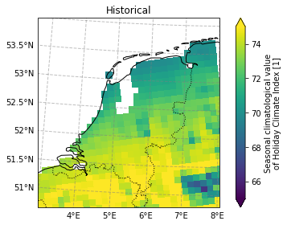

```python
# plt.figure()

ax = plt.axes(projection=ccrs.UTM(32))

HCI_jja_hist['hci-proj'].sel(rlat = slice (0,4),
                                 rlon = slice (-10,-6)).plot(
    transform=ccrs.RotatedPole(
        pole_longitude = -162.0,
        pole_latitude = 39.25,
    ),
    vmin = 65,
    vmax = 75,
    ax=ax
)

ax.coastlines(resolution='10m')
ax.add_feature(cartopy.feature.BORDERS, linestyle=':')
gl = ax.gridlines(crs=ccrs.PlateCarree(),
                  draw_labels=True,     # cannot label OSGB projection..
                  linewidth=1,
                  color='gray',
                  alpha=0.5,
                  linestyle='--')
gl.top_labels = False
gl.right_labels = False
ax.set_extent([3, 8, 50.8, 54])
ax.set_title('Historical')
plt.tight_layout()
plt.savefig('./Graphs/Urban_NL.png', dpi=300)
```

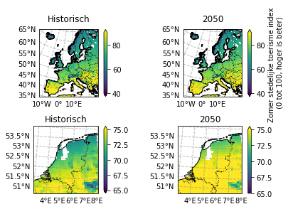

```python
fig, axs = plt.subplots(2, 2, subplot_kw={'projection': ccrs.EuroPP()})

##Topleft panel
HCI_jja_hist['hci-proj'].plot(
    transform=ccrs.RotatedPole(
        pole_longitude = -162.0,
        pole_latitude = 39.25,
    ),
    vmin = 40,
    vmax = 90,
    ax=axs[0,0],
    cbar_kwargs={'label': ""}
)

##Topright panel
HCI_jja_proj['hci-proj'].plot(
    transform=ccrs.RotatedPole(
        pole_longitude = -162.0,
        pole_latitude = 39.25,
    ),
    vmin = 40,
    vmax = 90,
    ax=axs[0,1],
    cbar_kwargs={'label': "Zomer stedelijke toerisme index \n (0 tot 100, hoger is beter)"}
)

##Bottomleft panel
HCI_jja_hist['hci-proj'].sel(rlat = slice (0,4),
                                 rlon = slice (-10,-6)).plot(
    transform=ccrs.RotatedPole(
        pole_longitude = -162.0,
        pole_latitude = 39.25,
    ),
    vmin = 65,
    vmax = 75,
    ax=axs[1,0],
    cbar_kwargs={'label': ""}
)

##Bottomright panel
HCI_jja_proj['hci-proj'].sel(rlat = slice (0,4),
                                 rlon = slice (-10,-6)).plot(
    transform=ccrs.RotatedPole(
        pole_longitude = -162.0,
        pole_latitude = 39.25,
    ),
    vmin = 65,
    vmax = 75,
    ax=axs[1,1],
    cbar_kwargs={'label': ""}
)

for ax in axs.flat:
    ax.coastlines(resolution='10m')
    ax.add_feature(cartopy.feature.BORDERS, linestyle=':')
    gl = ax.gridlines(crs=ccrs.PlateCarree(),
                  draw_labels=True,     # cannot label OSGB projection..
                  linewidth=1,
                  color='gray',
                  alpha=0.5,
                  linestyle='--')
    gl.top_labels = False
    gl.right_labels = False

axs[1,0].set_extent([3, 8, 50.8, 54])
axs[1,1].set_extent([3, 8, 50.8, 54])
axs[0,0].set_title('Historisch')
axs[0,1].set_title('2050')
axs[1,0].set_title('Historisch')
axs[1,1].set_title('2050')

plt.tight_layout()
plt.savefig('./Graphs/Urban.pdf', dpi=300)
```

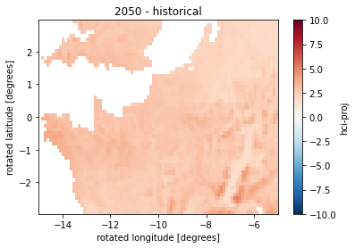

```python
p = HCI_proj_min_hist.sel(rlat = slice (-3,3),
                      rlon = slice (-15,-5)).plot(
    vmin = -10,
    vmax = 10,
    cmap=plt.cm.RdBu_r
)

plt.title('2050 - historical')
plt.savefig('./Graphs/HCI_jja_change_zoom.png')
```

#### Find a lat long point in the rotated coordinate system

Below I find the values for the point lon 4,5 and lat 52

- Historical: 72.85
- 2050: 75

```python
data_crs = ccrs.RotatedPole(
        pole_longitude = -162.0,
        pole_latitude = 39.25,
    )
```

```python
# Transform the point - src_crs is always Plate Carree for lat/lon grid
lon, lat = data_crs.transform_point(x = 4.49882022,
                                y = 52.02109482,
                                src_crs=ccrs.PlateCarree())
```

```python
# Now you can select data
HCI_jja_hist['hci-proj'].sel(rlon=lon, rlat=lat, method="nearest")
```

```
<xarray.DataArray 'hci-proj' (time: 1)>
array([72.84859916])
Coordinates:
    rlat     float64 2.035
    rlon     float64 -8.245
  * time     (time) object 1995-07-15 00:00:00
    lon      float64 4.529
    lat      float64 52.03
Attributes:
    units:          1
    long_name:      Seasonal climatological value of Holiday Climate Index
    short_name:     hci-proj
    standard_name:  hci-proj
    cell_methods:   time: mean within years time: mean over years
    grid_mapping:   rotated_latitude_longitude
```

```python
HCI_jja_proj['hci-proj'].sel(rlon=lon, rlat=lat, method="nearest")
```

```
<xarray.DataArray 'hci-proj' (time: 1)>
array([75.09066607])
Coordinates:
    rlat     float64 2.035
    rlon     float64 -8.245
  * time     (time) object 2050-07-15 00:00:00
    lon      float64 4.529
    lat      float64 52.03
Attributes:
    units:          1
    long_name:      Seasonal climatological value of Holiday Climate Index
    short_name:     hci-proj
    standard_name:  hci-proj
    cell_methods:   time: mean within years time: mean over years
    grid_mapping:   rotated_latitude_longitude
```

## The Climate Index for Tourism (CIT) for *Beach tourism*

- good conditions: CIT = 5,6,7
- fair conditions: CIT = 4
- unfavorable conditions: CIT = 0,1,2,3

### Download data

The below code retrieves the data for our selection. Note that you need to set up the API for CDS, see more [here](https://cds.climate.copernicus.eu/api-how-to) on how to do so.

```python
# c = cdsapi.Client()

# c.retrieve(
#     'sis-tourism-climate-suitability-indicators',
#     {
#         'climate_index': 'climate_index_for_tourism',
#         'variable': 'daily_index',
#         'product_type': 'multi_model_mean',
#         'time_aggregation': [
#             'autumn', 'spring', 'summer',
#             'winter',
#         ],
#         'experiment': 'rcp8_5',
#         'period': '2041_2060',
#         'format': 'zip',
#     },
#     'download_projections.zip')
```

```python
# c = cdsapi.Client()

# c.retrieve(
#     'sis-tourism-climate-suitability-indicators',
#     {
#         'climate_index': 'climate_index_for_tourism',
#         'variable': 'daily_index',
#         'product_type': 'multi_model_mean',
#         'time_aggregation': [
#             'autumn', 'spring', 'summer',
#             'winter',
#         ],
#         'experiment': 'historical',
#         'period': '1986_2005',
#         'format': 'zip',
#     },
#     'download.zip')
```

### Load data

```python
CIT_jja_hist = xr.open_dataset('./Data/Beach_CIT/Historical/C3S422Lot2TEC_cit-proj_mean_jja_1986_2005_v1.nc')
```

```python
CIT_jja_proj = xr.open_dataset('./Data/Beach_CIT/RCP85_2050/C3S422Lot2TEC_cit-proj_mean_jja_2041_2060_v1.nc')
```

Lets have a look at the xarray dataset for future projections:

```python
CIT_jja_proj
```

```
<xarray.Dataset>
Dimensions:             (rlat: 412, rlon: 424, time: 1, bnds: 2)
Coordinates:
  * rlat                (rlat) float64 -23.38 -23.27 -23.16 ... 21.73 21.84
  * rlon                (rlon) float64 -28.38 -28.27 -28.16 ... 18.05 18.16
  * time                (time) object 2050-07-15 00:00:00
    lon                 (rlat, rlon) float64 ...
    lat                 (rlat, rlon) float64 ...
Dimensions without coordinates: bnds
Data variables:
    cit-proj            (time, rlat, rlon) float64 ...
    rotated_pole        |S1 b''
    climatology_bounds  (time, bnds) object 2041-06-01 00:00:00 2060-09-01 00...
Attributes: (12/14)
    Conventions:    CF-1.7
    title:          Climate Index for Tourism (CIT) scenario seasonal climato...
    references:     de Freitas et al. 2008, https://doi.org/10.1007/s00484-00...
    source:         Processing of ECVs from EURO-CORDEX climate projections
    institution:    CMCC, Centro Euro-Mediterraneo sui Cambiamenti Climatici,...
    contact:        http://copernicus-support.ecmwf.int
    ...             ...
    comment:        Ensemble mean over selected EURO-CORDEX projections of JJ...
    history:
    lineage:
    summary:        CIT projection data produced by CMCC as its contribution ...
    keywords:       Climate Index for Tourism, Climate Projections, C3S, Euro...
    license:
```

### Making the maps

With the data loaded, we can now make some plots of the data! Read more about plotting with xarray [here](https://docs.xarray.dev/en/stable/user-guide/plotting.html#two-dimensions).

- good conditions: CIT = 5,6,7
- fair conditions: CIT = 4
- unfavorable conditions: CIT = 0,1,2,3

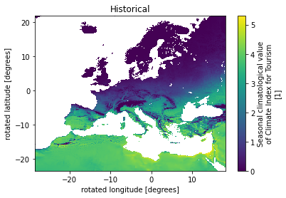

```python
CIT_jja_hist['cit-proj'].plot()
plt.title('Historical')
plt.savefig('./Graphs/CIT_jja_hist.png')
```

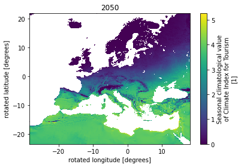

```python
CIT_jja_proj['cit-proj'].plot()
plt.title('2050')
plt.savefig('./Graphs/CIT_jja_RCP85_2050.png')
```

I now calculate the difference between the projection and historical data. Note that I need to load the data in memory first before doing the calculation and I need to drop the time dimension.

```python
CIT_jja_hist.load()
CIT_jja_proj.load()
CIT_proj_min_hist = (CIT_jja_proj['cit-proj'].drop('time')-CIT_jja_hist['cit-proj'].drop('time'))
```

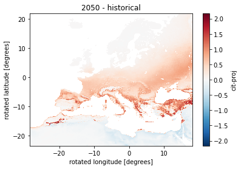

```python
CIT_proj_min_hist.plot()
plt.title('2050 - historical')
plt.savefig('./Graphs/CIT_jja_change.png')
```

#### More advanced plotting and Zooming in on Zuid-Holland

We want to zoom in on Zuid-Holland. The data has this odd 'rotated' latitude and longitude, such that the original values for Zuid Holland (~52, ~4.5) don't translate. Therefore I am setting up a new projection and transform the rotated pole onto it.

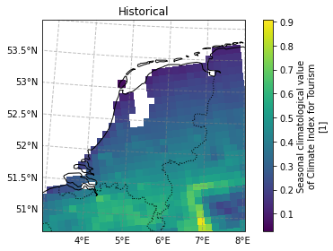

```python
# plt.figure()

ax = plt.axes(projection=ccrs.UTM(32))

CIT_jja_hist['cit-proj'].sel(rlat = slice (0,4),
                                 rlon = slice (-10,-6)).plot(
    transform=ccrs.RotatedPole(
        pole_longitude = -162.0,
        pole_latitude = 39.25,
    ),
#     vmin = 65,
#     vmax = 75,
    ax=ax
)

ax.coastlines(resolution='10m')
ax.add_feature(cartopy.feature.BORDERS, linestyle=':')
gl = ax.gridlines(crs=ccrs.PlateCarree(),
                  draw_labels=True,     # cannot label OSGB projection..
                  linewidth=1,
                  color='gray',
                  alpha=0.5,
                  linestyle='--')
gl.top_labels = False
gl.right_labels = False
ax.set_extent([3, 8, 50.8, 54])
ax.set_title('Historical')
plt.tight_layout()
plt.savefig('./Graphs/Beach_NL.png', dpi=300)
```

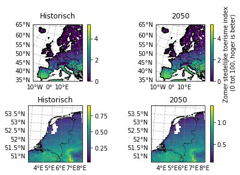

```python
fig, axs = plt.subplots(2, 2, subplot_kw={'projection': ccrs.EuroPP()})

##Topleft panel
CIT_jja_hist['cit-proj'].plot(
    transform=ccrs.RotatedPole(
        pole_longitude = -162.0,
        pole_latitude = 39.25,
    ),
#     vmin = 40,
#     vmax = 90,
    ax=axs[0,0],
    cbar_kwargs={'label': ""}
)

##Topright panel
CIT_jja_proj['cit-proj'].plot(
    transform=ccrs.RotatedPole(
        pole_longitude = -162.0,
        pole_latitude = 39.25,
    ),
#     vmin = 40,
#     vmax = 90,
    ax=axs[0,1],
    cbar_kwargs={'label': "Zomer stedelijke toerisme index \n (0 tot 100, hoger is beter)"}
)

##Bottomleft panel
CIT_jja_hist['cit-proj'].sel(rlat = slice (0,4),
                                 rlon = slice (-10,-6)).plot(
    transform=ccrs.RotatedPole(
        pole_longitude = -162.0,
        pole_latitude = 39.25,
    ),
#     vmin = 65,
#     vmax = 75,
    ax=axs[1,0],
    cbar_kwargs={'label': ""}
)

##Bottomright panel
CIT_jja_proj['cit-proj'].sel(rlat = slice (0,4),
                                 rlon = slice (-10,-6)).plot(
    transform=ccrs.RotatedPole(
        pole_longitude = -162.0,
        pole_latitude = 39.25,
    ),
#     vmin = 65,
#     vmax = 75,
    ax=axs[1,1],
    cbar_kwargs={'label': ""}
)

for ax in axs.flat:
    ax.coastlines(resolution='10m')
    ax.add_feature(cartopy.feature.BORDERS, linestyle=':')
    gl = ax.gridlines(crs=ccrs.PlateCarree(),
                  draw_labels=True,     # cannot label OSGB projection..
                  linewidth=1,
                  color='gray',
                  alpha=0.5,
                  linestyle='--')
    gl.top_labels = False
    gl.right_labels = False

axs[1,0].set_extent([3, 8, 50.8, 54])
axs[1,1].set_extent([3, 8, 50.8, 54])
axs[0,0].set_title('Historisch')
axs[0,1].set_title('2050')
axs[1,0].set_title('Historisch')
axs[1,1].set_title('2050')

plt.tight_layout()
plt.savefig('./Graphs/Beach.pdf', dpi=300)
```

#### Find a lat long point in the rotated coordinate system

Below I find the values for the point lon 4,5 and lat 52

- Historical: 0.3
- 2050: 0.5

```python
# Now you can select data
CIT_jja_hist['cit-proj'].sel(rlon=lon, rlat=lat, method="nearest")
```

```
<xarray.DataArray 'cit-proj' (time: 1)>
array([0.29841099])
Coordinates:
    rlat     float64 2.035
    rlon     float64 -8.245
  * time     (time) object 1995-07-15 00:00:00
    lon      float64 4.529
    lat      float64 52.03
Attributes:
    units:          1
    long_name:      Seasonal climatological value of Climate Index for Tourism
    short_name:     cit-proj
    standard_name:  cit-proj
    cell_methods:   time: mean within years time: mean over years
    grid_mapping:   rotated_latitude_longitude
```

```python
CIT_jja_proj['cit-proj'].sel(rlon=lon, rlat=lat, method="nearest")
```

```
<xarray.DataArray 'cit-proj' (time: 1)>
array([0.48813023])
Coordinates:
    rlat     float64 2.035
    rlon     float64 -8.245
  * time     (time) object 2050-07-15 00:00:00
    lon      float64 4.529
    lat      float64 52.03
Attributes:
    units:          1
    long_name:      Seasonal climatological value of Climate Index for Tourism
    short_name:     cit-proj
    standard_name:  cit-proj
    cell_methods:   time: mean within years time: mean over years
    grid_mapping:   rotated_latitude_longitude
```